# Formatting text in Quarto

Session - Text

Zoë Turner

## Markdown

Quarto reports support text and code with the text being `Markdown`

**Q**uarto **M**ark**d**own

`.qmd` file

## Headers

```markdown
# HEADER 1

## HEADER 2

### HEADER 3

#### HEADER 4

##### HEADER 5

###### HEADER 6
```

**Watch the spaces! (warning)**

Make sure that there is a space between the hashes!

#Example no space!

## Navigating headers in RStudio

[figure not shown]

## Headers and chunk table of contents

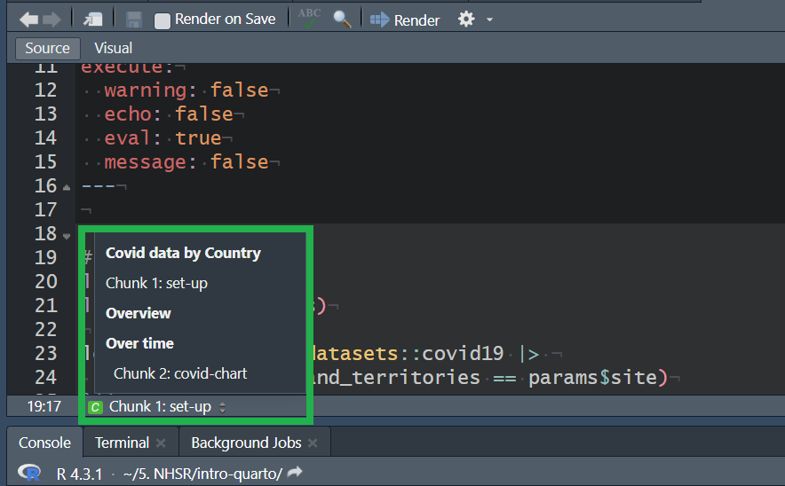

## Formatting Text

Text formatting uses [markdown](https://www.markdownguide.org/basic-syntax/)

```markdown
**Bold**
_Italic_
*Also Italic *
***Bold and italic***
```

**Bold**  
*Italic*  
*Also Italic*  
*Bold and italic*

**Underlining is missing**

Whilst underlining can be done using using html it’s not accessible for everyone and can be confused with hyperlinks so is best avoided

## Lists

Bullets can be created with `*` or `-` and numbers can be `1.` repeated

```markdown
- Patient (_Unique NHS Number_)
- Referral (_Not unique_)
* Contact (_Not unique_)
* Diagnoses (_Multiple entries_)

These data types occur in various places

1. Mental Health
1. Outpatients
1. GPs
```

- Patient (*Unique NHS Number*)
- Referral (*Not unique*)
- Contact (*Not unique*)
- Diagnoses (*Multiple entries*)

These data types occur in various places

1. Mental Health
2. Outpatients
3. GPs

## When lists don’t work

**Spaces!**

- A return space is needed to separate the list from preceding text
- Spaces between the bullet symbol and text are also required
- Separating lines that are not in bullets can be done with two spaces at the end

Copy this to `covid-analysis.qmd` and correct the issues

```markdown
Check the spacing:
- This is right up against the text

-This is missing a space
*Also missing a space

These two lines
need to be separated using two space
```

`06:00`

## Hyperlink

### Using markdown and brackets `[]()`

Using the `[]` for the words:

```markdown
Sign up to free events through the [NHS-R Community](https://nhsrcommunity.com/) website
```

Sign up to free events through the [NHS-R Community](https://nhsrcommunity.com/) website

## Next Section

[figure not shown]